# Twine Extraction Activity Surveys

# Survey Questions

| Code | Question |
| --- | --- |
| bf_how | BEFORE lab lecture today, how comfortable would you feel if asked to explain HOW acid-base extraction works at the molecular level? (Likert) |
| bf_why | BEFORE class, how comfortable would you feel if asked to explain WHY taking advantage of acid-base chemistry makes acid-base extraction possible? (Likert) |
| aft_how | AFTER class, how comfortable would you feel if asked to explain HOW acid-base extraction works at the molecular level? (Likert) |
| aft_why | AFTER class, how comfortable would you feel if asked to explain WHY taking advantage of acid-base chemistry makes acid-base extraction possible? (Likert) |
| pair_true | Which pair of statements is completely true? |
| usability | How would you rate the usability of the extraction activity? (Likert) |

### pair_true options

- Adding strong acid to benzoic acid (dissolved in organic solvent) will cause deprotonation of benzoic acid (now negatively charged). The compound was in the aqueous layer, but after mixing it is in the organic layer. *(coded as acid_org)*
- Adding strong acid to benzoic acid (dissolved in organic solvent) will cause deprotonation of benzoic acid (now negatively charged). The compound was in the organic layer, but after mixing it is in the aqueous layer. *(coded as acid_aq)*
- Adding strong base to benzoic acid (dissolved in organic solvent) will cause deprotonation of benzoic acid (now negatively charged). The compound was in the aqueous layer, but after mixing it is in the organic layer. *(coded as base_org)*
- Adding strong base to benzoic acid (dissolved in organic solvent) will cause deprotonation of benzoic acid (now negatively charged). The compound was in the organic layer, but after mixing it is in the aqueous layer. *(coded as base_aq)*

# Summary Statistics for Complete Sets

```
── Data Summary ────────────────────────
                           Values
Name                       Piped data
Number of rows             1071
Number of columns          9
_______________________
Column type frequency:
  factor                   4
  numeric                  5
________________________
Group variables            None

── Variable type: factor ────────────────────────────────────────────────────────────────
  skim_variable        n_missing complete_rate ordered n_unique
1 pair_true_pre_short          0             1 FALSE          4
2 pair_true_post_short         0             1 FALSE          4
3 pair_true_pre                0             1 FALSE          4
4 pair_true_post               0             1 FALSE          4
  top_counts
1 bas: 701, bas: 272, aci: 53, aci: 45
2 bas: 757, bas: 211, aci: 62, aci: 41
3 Add: 701, Add: 272, Add: 53, Add: 45
4 Add: 757, Add: 211, Add: 62, Add: 41

── Variable type: numeric ───────────────────────────────────────────────────────────────
  skim_variable n_missing complete_rate  mean    sd    p0   p25   p50   p75  p100 hist
1 how_pre               0             1  4.01 1.40      1     3     4     5     7 ▅▆▅▇▅
2 why_pre               0             1  3.63 1.37      1     3     4     5     7 ▆▇▆▆▃
3 how_post              0             1  5.32 0.991     1     5     5     6     7 ▁▁▂▆▇
4 why_post              0             1  5.17 1.04      1     5     5     6     7 ▁▁▃▇▇
5 usability             0             1  6.14 1.02      1     6     6     7     7 ▁▁▁▂▇
```

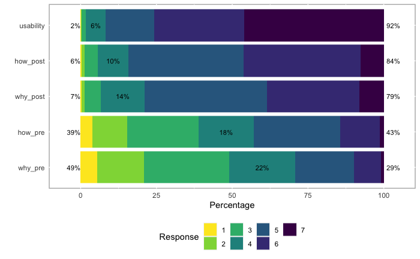

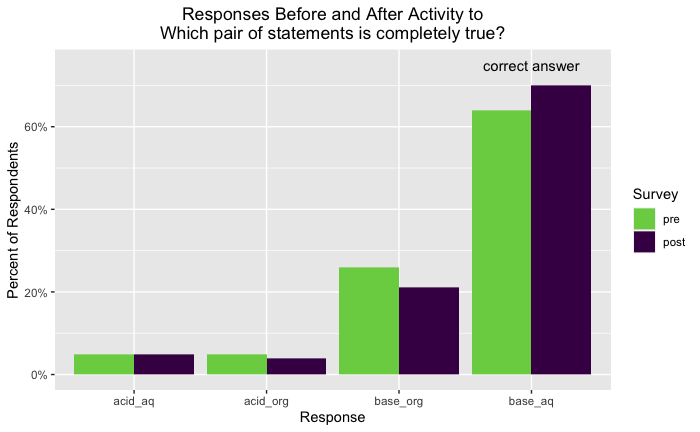